# Loading Spatial Data

Author

Will Gammerdinger, Noor Sohail, Zhu Zhuo, James Billingsley, Shannan Ho Sui

Published

July 22, 2025

# Learning Objectives

- Establish a hypothesis or biological question to assess using the provided dataset
- Quantify how bin size affects the count matrix
- Utilize functions to grab important information from each Seurat data structure slots
- Create a Seurat object from SpaceRanger outputs

# The Dataset

## Metadata

**Human CRC**

Human colorectal cancer sample

Matched control and cancerous colon sample from 58 year old female in stage IV-A.

- [Natural (control)](https://www.10xgenomics.com/platforms/visium/product-family/dataset-human-crc)
- [Colorectal Cancer](https://www.10xgenomics.com/platforms/visium/product-family/dataset-human-crc)

With the associated [paper](https://www.nature.com/articles/s41588-025-02193-3)

We expect to see the following celltypes in our dataset:

- B cells
- T cells
- Tumor
- Myeloid
- Fibroblast
- Endothelial
- Intestinal Epithelial
- Smooth Muscle
- Neuronal

**Mouse Brain**

A mouse brain (fresh frozen) was obtained from Charles River Laboratories.

Strain: C57BL/6 Sex: Male Age: 8 weeks Sample preparation

A 10 µm section was taken with a cryostat (Epredia CryoStar NX70). Tissue block preparation, sectioning, H&E staining, and imaging followed the Visium HD Fresh Frozen Tissue Preparation Handbook (CG000763).

The data was subset to a smaller cross-section of the brain in order to make it more manageable on local laptops. The instructions for how to subset a 10X Visium HD slides can be found here.

**Exercise 1**

1. Given the information that we know from the metadata, what might be some questions that we want to answer using our data?

## Downloading the R Project and Data

We have assembled an R Project for you to download that includes the data along with a basic file structure for maintain good data management. It can be quite easy when starting a new analysis to want to dive right in and start analyzing your data. However, good data management practices occur at each step of data’s lifecycle. It is a good habit to begin by creating a basic directory structure to hold your data. Let’s start by download this R Project and data from here. Left-click on the link and select `Save Link As..` or `Download Linked File As..`, then select a place on your computer where you would like to place this R Project.

```r
# Creating Seurat object from SpaceRanger output
# Visium HD spatial transcriptomics workshop
# Author: Harvard Chan Bioinformatics Core
# Created: December 2025

library(tidyverse)
library(Seurat)
```

# Loading Data into a Seurat Object

There are several different workflow that can used for analyzing spatial transcriptomics data. While each has their own nuances, they all follow the same fundamental theory and processes:

- Python’s [Squidpy](https://squidpy.readthedocs.io/en/stable/)
- R’s [Spatial Experiment](https://bioconductor.org/packages/release/bioc/html/SpatialExperiment.html)
- R’s [Seurat](https://satijalab.org/seurat/).

**As this in an R-based workshop, we will be using Seurat.**

## Data Files

To load our data, we are going to make use of the function `Load10X_Spatial()`. The input needed for this function comes from the output generated by SpaceRanger, including both the feature matrix and low-resolution tissue image. Once supplied, a Seurat object that contains our counts matrix and image is created.

**Using `?` to look up function arguments**

If you are ever unsure what parameters you can supply to a function, you make use of the `?` call in R. This will bring up the manual page for the function while will provide more details on what each variable is used for.

```r
?Load10X_Spatial
```

There are 3 main arguments that we will be utilizing for this step:

Table 1: `Load10X_Spatial()` arguments

| Argument | Description |
| --- | --- |
| data.dir | Directory containing the H5 file specified by filename and the image data in a subdirectory called spatial |
| bin.size | Specifies the bin sizes to read in (defaults to c(16, 8)) |
| slice | Name for the stored image of the tissue slice |

Before loading in the data, let us take a look at the files we will supplying to the function. In particular, let us take a look at sample `data/P5CRC_cropped` which is the path would supply as `data.dir` in the `Load10X_Spatial()` function.

```
data/P5CRC_cropped/
└── binned_outputs
    ├── square_008um
    └── square_016um
```

In the Visium HD assay, SpaceRanger bins the image into 2µm x 2µm, 8µm x 8µm, and 16µm x 16µm bins. **The output from each of these resolution is found in the `binned_outputs` folder.**

**Choosing your bin size**

This is not an easy question to answer!

The typical recommendation for a Visium HD analysis is to use the 8µm x 8µm resolution of the dataset. However, it is important to consider the dataset you are working with. For example, neuron cells are know to be a larger celltype in size. Therefore it would be good to consider a large bin size in order to fully represent each cell within a bin.

There are numerous algorithms that have been created to identify the boundaries of cells to ensure that counts are being associated with single-cells. This process is typically referred to as segmentation, which we will cover in a later lesson.

## Creating the Seurat Object

Now that we understand the input needed for the `Load10X_Spatial()` function, let’s use it to create a Seurat object called `crc`. We will specify that we want to load in the `8µm` and `16µm` bin sizes at the same time.

**Typically you would only load in one bin size**, but for the purposes of better understanding bins and our Seurat data structure, we will load both here.

```r
crc <- Load10X_Spatial(data.dir = "data/P5CRC_cropped/",
                       bin.size = c(8, 16),
                       slice = "P5CRC")
```

We can print out some basic information of our Seurat object to examine its data structure. We will do this frequently throughout the workshop to understand how our the Seurat data structure changes with each step of the workflow.

```r
crc
```

```
An object of class Seurat
36170 features across 259572 samples within 2 assays
Active assay: Spatial.008um (18085 features, 0 variable features)
 1 layer present: counts
 1 other assay present: Spatial.016um
 2 spatial fields of view present: P5CRC.008um P5CRC.016um
```

## Anatomy of a Seurat Object

As we can see from our Seurat callout, there are a lot of different slots inside our object. Here, we will go through each of the major components of a Seurat object and how you would access key pieces of information.

### Assays

`Assays` are where we can store different counts matrices - we are not forced to keep the same features and variable genes across assays. Each assay will contain it’s own `Layers` that can be distinct from other assays in the object. This is useful in several different cases:

- Multi-modal assays, where you can keep the expression matrices for RNA, ATAC, or protein in a single Seurat object
- Storing counts matrices from a variety of different normalization techniques
- Batch integration methods will sometimes generate a transformed counts matrix

Here we can print the different assays that exist within our `crc` object:

```r
Assays(crc)
```

```
[1] "Spatial.008um" "Spatial.016um"
```

We have 2 distinct assays for the different bin sizes, which makes sense because we have different count matrices for our cells based upon the bin size that was selected.

The `DefaultAssay()` function shows us which assay information will be used in other Seurat function calls, unless explicitly specified otherwise.

```r
DefaultAssay(crc)
```

```
[1] "Spatial.008um"
```

We can also change what our default assay is. Let’s set it to the `016um` bins:

```r
DefaultAssay(crc) <- "Spatial.016um"
crc
```

```
An object of class Seurat
36170 features across 259572 samples within 2 assays
Active assay: Spatial.016um (18085 features, 0 variable features)
 1 layer present: counts
 1 other assay present: Spatial.008um
 2 spatial fields of view present: P5CRC.008um P5CRC.016um
```

Now we see that the callout says: `Active assay: Spatial.016um`

### Features and Cells

Our count matrices function as any other matrix does, with rows and columns.

In Seurat, the **rows** correspond to `Features`. In the case of spatial transcriptomics, our features are genes. In other experiments, features could refer to chromatin peaks or proteins. The important thing to keep in mind is what technology you are using. Since this is a Visium HD dataset, we are quantifying RNA expression (genes).

We can see what the first few genes/features in our count matrix are:

```r
Features(crc) %>% head()
```

```
[1] "SAMD11"  "NOC2L"   "KLHL17"  "PLEKHN1" "PERM1"   "HES4"
```

As well as see the number of genes that are found in each of our assays:

```r
nrow(crc[["Spatial.008um"]])
```

```
[1] 18085
```

```r
nrow(crc[["Spatial.016um"]])
```

```
[1] 18085
```

The **columns** correspond to `Cells` (or samples as it appears in the callout). We can see what the first few cells in our count matrix are:

```r
Cells(crc) %>% head()
```

```
[1] "s_016um_00050_00315-1" "s_016um_00204_00145-1" "s_016um_00237_00273-1"
[4] "s_016um_00224_00126-1" "s_016um_00191_00159-1" "s_016um_00064_00214-1"
```

As well as see the number of cells that are found in each of our assays:

```r
ncol(crc[["Spatial.008um"]])
```

```
[1] 207393
```

```r
ncol(crc[["Spatial.016um"]])
```

```
[1] 52179
```

**Exercise 2**

2. What differences do you see between the `8um` and `16um` bins?

### Layers

Layers are our count matrices.

```r
Layers(crc)
```

```
[1] "counts"
```

By default, Seurat uses the following naming convention for the counts matrices within an `Assay`:

Table 2: Description of each `Layer()` count matrix

| Layer | Description |
| --- | --- |
| counts | Raw counts |
| data | Normalized counts |
| scale.data | Scaled‑normalized counts |

You may notice that our Seurat object only contains `counts` right now. This is because we have not run any normalization steps yet (we will discuss how to do so in future lessons).

Using the `LayerData()` function we can access the entire counts matrix. Furthermore, we can specify the `assay` if we would prefer to not use the `DefaultAssay`.

```r
LayerData(crc,
          assay = "Spatial.016um",
          layer = "count")[1:5, 1:5]
```

Table 3: First 5 rows and columns of raw counts matrix

|  | s_016um_00050_00315-1 | s_016um_00204_00145-1 | s_016um_00237_00273-1 | s_016um_00224_00126-1 | s_016um_00191_00159-1 |
| --- | --- | --- | --- | --- | --- |
| SAMD11 | 0 | 0 | 0 | 0 | 0 |
| NOC2L | 0 | 0 | 0 | 0 | 0 |
| KLHL17 | 0 | 0 | 0 | 0 | 0 |
| PLEKHN1 | 0 | 0 | 0 | 0 | 0 |
| PERM1 | 0 | 0 | 0 | 0 | 0 |

By printing the first 5 features and cells in our object (for easier visualization). We can see that we are working with **whole numbers** which reinforces the idea that this is the **raw data**, with no transformations having been applied.

### Spatial Fields

We do not just have expression data associated with our sample, we also have the spatial slide that comes with its own set of values and information.

For example we can grab the x,y coordinates of each bin using the `GetTissueCoordinates()` function.

```r
GetTissueCoordinates(crc) %>% View()
```

Table 4: Coordinates on spatial slide for each cell

|  | x | y | cell |
| --- | --- | --- | --- |
| s_016um_00050_00315-1 | 61103.61677064034 | 62715.75626099607 | s_016um_00050_00315-1 |
| s_016um_00204_00145-1 | 52062.96743045275 | 52817.77672271128 | s_016um_00204_00145-1 |
| s_016um_00237_00273-1 | 50165.22793639079 | 60306.09275558939 | s_016um_00237_00273-1 |
| s_016um_00224_00126-1 | 50889.64019839198 | 51712.24586588216 | s_016um_00224_00126-1 |
| s_016um_00191_00159-1 | 52826.0316294568 | 53632.80295489775 | s_016um_00191_00159-1 |

Or visualize what our slide looks like with `SpatialDimPlot()`:

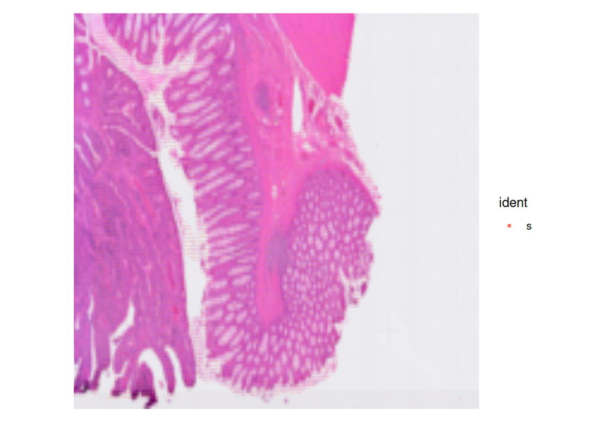

Figure 1: Spatial visualization of spots with `SpatialDimPlot()`

```r
SpatialDimPlot(crc)
```

### Metadata

**Seurat automatically creates some metadata** for each of the cells when the object is created. This information is stored in the `@meta.data` slot within the Seurat object. The rownames are automatically set to be the cell names.

```r
crc@meta.data %>% View()
```

Table 5: Seurat default `@meta.data`

|  | orig.ident | nCount_Spatial.008um | nFeature_Spatial.008um | nCount_Spatial.016um | nFeature_Spatial.016um |
| --- | --- | --- | --- | --- | --- |
| s_008um_00078_00444-1 | s | 65 | 57 |  |  |
| s_008um_00128_00278-1 | s | 1300 | 906 |  |  |
| s_008um_00052_00559-1 | s | 128 | 121 |  |  |
| s_008um_00121_00413-1 | s | 538 | 326 |  |  |
| s_008um_00447_00253-1 | s | 201 | 166 |  |  |

What does each column represent?

Table 6: Columns automatically populated in `@meta.data`

| Column | Description |
| --- | --- |
| orig.ident | Sample identity if known; defaults to “s” |
| nCount_RNA | Number of UMIs per cell |
| nFeature_RNA | Number of genes detected per cell |

While it may seem intimidating at first, the important thing to remember is that this is a dataframe. Therefore can modify and work with this dataframe just like we would any other in R! For example, we can set our `orig.ident` column to be our sample name rather than “s”.

```r
crc@meta.data$orig.ident <- "P5CRC"
```

```r
crc@meta.data %>% View()
```

Table 7: Seurat default `@meta.data` after updating `orig.ident`

|  | orig.ident | nCount_Spatial.008um | nFeature_Spatial.008um | nCount_Spatial.016um | nFeature_Spatial.016um |
| --- | --- | --- | --- | --- | --- |
| s_008um_00078_00444-1 | P5CRC | 65 | 57 |  |  |
| s_008um_00128_00278-1 | P5CRC | 1300 | 906 |  |  |
| s_008um_00052_00559-1 | P5CRC | 128 | 121 |  |  |
| s_008um_00121_00413-1 | P5CRC | 538 | 326 |  |  |
| s_008um_00447_00253-1 | P5CRC | 201 | 166 |  |  |

Additionally, we do not have use the `@meta.data` each time we want to access a single column. We can use the `$` follow by the column name as a shorthand.

```r
crc$nCount_Spatial.008um %>% head()
```

```
s_008um_00078_00444-1 s_008um_00128_00278-1 s_008um_00052_00559-1
                   65                  1300                   128
s_008um_00121_00413-1 s_008um_00447_00253-1 s_008um_00455_00433-1
                  538                   201                   164
```

### Idents

The cell identities are stored as `Idents()`, which contain the default way to label cells. For example, if we wanted to label each cell by which sample they came from we could run:

```r
Idents(crc) <- "orig.ident"
Idents(crc) %>% head()
```

```
s_008um_00078_00444-1 s_008um_00128_00278-1 s_008um_00052_00559-1
                P5CRC                 P5CRC                 P5CRC
s_008um_00121_00413-1 s_008um_00447_00253-1 s_008um_00455_00433-1
                P5CRC                 P5CRC                 P5CRC
Levels: P5CRC
```

Where we see that the identities of the cells are the value stored in the `@meta.data` column `orig.ident`.

# Loading Multiple Samples into Seurat

Before we begin, we are going to remove the `crc` object we have been playing with in order to clear up extra space on our computers. Spatial transcriptomics take up a lot of memory! So we are being careful to remove any variables that might overload the RAM.

```r
rm(crc)
```

Now that we have a better understanding of how to create a Seurat object from SpaceRanger outpus, let’s go through how we can load multiple samples at once. In this case we want to represent both samples `P5CRC` and `P5NAT` in a singular Seurat object.

## Using a `for` Loop

In practice, you will likely have several samples that you will need to read in data for, and that can get tedious and error-prone if you do it one at a time. So, to make the data import into R more efficient we can use a `for` loop, which will iterate over a series of commands for each of the inputs given and create Seurat objects for each of our samples.

**`for` loop syntax**

In R, the `for` loop has the following structure/syntax:

```r
## DO NOT RUN

for (variable in input){
    command1
    command2
    command3
}
```

Today we will use it to **iterate over the two sample folders** and execute commands for each sample as we did above for a single sample:

1. Create the Seurat objects from the SpaceRanger data (`Load10X_Spatial()`) and specify `slice` so that images are labeled with their sample name
2. Set `orig.ident` to be our sample

Once those steps run, we will store the newly generated Seurat object to a list called `list_seurat` so that we can eventually merge both samples together.

**We will be using a bin size of 16um for the remainder of this workshop!**

```r
samples <- c("P5CRC", "P5NAT")
list_seurat <- list()

for (sample in samples) {

  # Path to data directory
  data_dir <- paste0("data/", sample, "_cropped")
  # Create seurat object and set orig ident to be sample
  seurat <- Load10X_Spatial(data.dir = data_dir,
                            bin.size = c(16),
                            slice = sample)
  seurat$orig.ident <- sample

  # Store seurat object in our list
  list_seurat[[sample]] <- seurat
}
```

To confirm that we succesfully loaded both samples in, we can take a look at the contents of `list_seurat`. We should see that there are two Seurat objects in our list that correspond to each sample.

```r
list_seurat
```

```
$P5CRC
An object of class Seurat
18085 features across 52179 samples within 1 assay
Active assay: Spatial.016um (18085 features, 0 variable features)
 1 layer present: counts
 1 spatial field of view present: P5CRC.016um

$P5NAT
An object of class Seurat
18085 features across 25397 samples within 1 assay
Active assay: Spatial.016um (18085 features, 0 variable features)
 1 layer present: counts
 1 spatial field of view present: P5NAT.016um
```

This is exactly what we had hoped to see! So now we can move on to the next step which is merging the sample together into a singular Seurat object.

## Merge Datasets Together

We merge samples together because it make it easier to run the QC steps for both sample groups together. It also enables us to easily compare the data quality for all cells at one time

To create this combined Seurat object, we use the `merge()` function. Because the same cell IDs can be used for different samples, we add a **sample-specific prefix** to each of our cell IDs using the `add.cell.id` argument to ensure the cell names are unique.

```r
seurat_merged <- merge(x = list_seurat[["P5CRC"]],
                       y = list_seurat[["P5NAT"]],
                       add.cell.id = c("P5CRC", "P5NAT"))
seurat_merged
```

```
An object of class Seurat
18085 features across 77576 samples within 1 assay
Active assay: Spatial.016um (18085 features, 0 variable features)
 2 layers present: counts.1, counts.2
 2 spatial fields of view present: P5CRC.016um P5NAT.016um
```

From the callout we can see that we now have: `2 layers present: counts.1, counts.2`

**What if I am merging more than two samples?**

Seurat has functionality to merge many samples together. You can do this quite easily by adding all sample objects to the `y` argument in a vector format. An example is provided below, assuming you use the list structured we used previously:

```r
## DO NOT RUN
merged_seurat <- merge(x = seurat_list[[1]],
                       y = seurat_list[[2:length(seurat_list)]],
                       add.cell.id = names(seurat_list))
```

However, we do not want to have two distinct raw counts matrices (`counts.1` and `counts.2`). We want the counts for each sample to be concatenated together. This would be a single, large count matrix that represent each cell in the dataset. Seurat’s function `JoinLayers()` allows us to do just this.

```r
seurat_merged <- JoinLayers(seurat_merged)
```

**Exercise 3**

3. What function can we use to double check that we have a singular `counts` *layer*?

**Merging vs. Integration**

A common point of confusion is the distinction between **integration** and merging. In the field, integration is considered to be modifying either your counts or latent space in a way to correct for a batch variable. Whereas what we are doing now is **merging** or concatenating multiple samples together. This process of merging does not transform the values in the count matrices.

## Evaluating `merged_seurat`

Let’s also double check that we have the correct number of cells. First, let us see what the number of cells was for each sample:

```r
ncol(list_seurat[["P5CRC"]]) + ncol(list_seurat[["P5NAT"]])
```

```
[1] 77576
```

Which is the same as the number of samples in our Seurat callout!

```r
seurat_merged
```

```
An object of class Seurat
18085 features across 77576 samples within 1 assay
Active assay: Spatial.016um (18085 features, 0 variable features)
 1 layer present: counts
 2 spatial fields of view present: P5CRC.016um P5NAT.016um
```

If we look at the metadata of the merged object we should be able to see the prefixes in the rownames (`Cells`) as well as the updated `orig.ident` we set in the for loop earlier.

```r
# Check that the merged object has the appropriate sample-specific prefixes
seurat_merged@meta.data %>% head()
```

Table 8: First 5 rows of `@meta.data`

|  | orig.ident | nCount_Spatial.016um | nFeature_Spatial.016um |
| --- | --- | --- | --- |
| P5CRC_s_016um_00050_00315-1 | P5CRC | 80 | 75 |
| P5CRC_s_016um_00204_00145-1 | P5CRC | 81 | 73 |
| P5CRC_s_016um_00237_00273-1 | P5CRC | 278 | 225 |
| P5CRC_s_016um_00224_00126-1 | P5CRC | 692 | 511 |
| P5CRC_s_016um_00191_00159-1 | P5CRC | 35 | 34 |

```r
seurat_merged@meta.data %>% tail()
```

Table 9: Last 5 rows of `@meta.data`

|  | orig.ident | nCount_Spatial.016um | nFeature_Spatial.016um |
| --- | --- | --- | --- |
| P5NAT_s_016um_00118_00353-1 | P5NAT | 51 | 44 |
| P5NAT_s_016um_00075_00309-1 | P5NAT | 428 | 369 |
| P5NAT_s_016um_00074_00298-1 | P5NAT | 373 | 307 |
| P5NAT_s_016um_00003_00392-1 | P5NAT | 70 | 66 |
| P5NAT_s_016um_00144_00329-1 | P5NAT | 469 | 288 |

Lastly we want to make sure that the `Idents` of our cells is a useful piece of information, for example like `orig.ident`, which contains our sample IDs.

```r
Idents(seurat_merged) <- "orig.ident"
```

# Save!

Now is a great spot to save our `seurat_merged` object as the next step is going to be filtering.

```r
# Save integrated Seurat object
saveRDS(seurat_merged, "data/seurat_merged.RDS")
```

A good rule of thumb is to save your intermediate objects before doing any filtration or after running a computational step that takes a long time to run.